# Администрирование сетевых подсистем

## Внесение изменений в настройки внутреннего окружения виртуальной машины

На виртуальной машине server перейдем в каталог для внесения изменений в настройки внутреннего окружения /vagrant/provision/server/. В соответствующие подкаталоги поместим конфигурационные файлы Dovecot и Postfix.

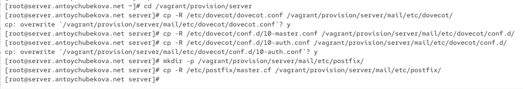

Внесение изменений в настройки внутреннего окружения виртуальной машины

## Внесение изменений в настройки внутреннего окружения виртуальной машины

Внесите соответствующие изменения по расширенной конфигурации SMTP-сервера в файл /vagrant/provision/server/mail.sh.

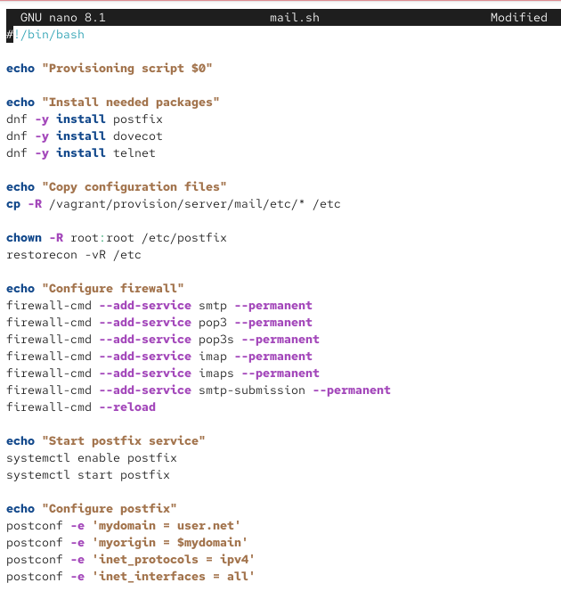

Редактирование исполняемого файла

## Внесение изменений в настройки внутреннего окружения виртуальной машины

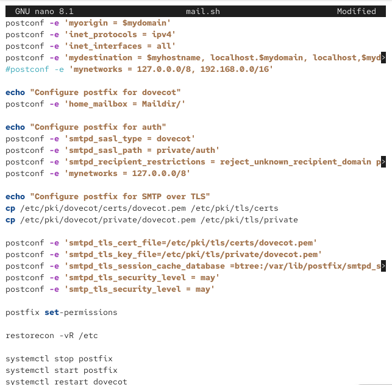

Редактирование исполняемого файла

## Внесение изменений в настройки внутреннего окружения виртуальной машины

Внесем изменения в файл /vagrant/provision/client/mail.sh, добавив установку telnet.

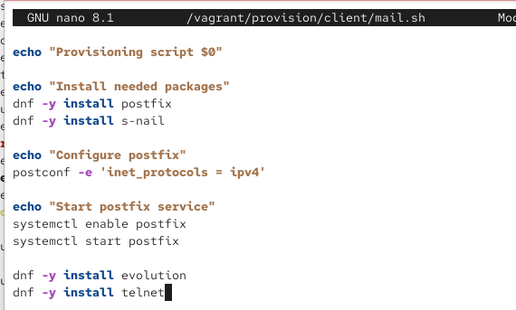

Редактирование исполняемого файла

# Выводы

## Выводы

В ходе выполнения лабораторной работы № 10 я приобрела практические навыков по конфигурированию SMTP-сервера в части настройки аутентификации.

# Список литературы

## Список литературы

1. Postfix SASL Howto. — URL: http : / / www . postfix . org / SASL _ README . html (visited on 09/13/2021).